# Diabetic Outcomes

Cormac Nolan

28 January 2018

```r
library(tidyverse)
library(cluster)
library(knitr)
library(Rtsne)
library(FactoMineR)
library(factoextra)

diabetes_raw <-
  read_csv("./data/dataset_diabetes/diabetic_data.csv", na='?') %>%
  mutate_if(is.character, factor)
```

```r
calc_silhouette <- function(distances, k){
  silhouette_width <- c(NA)
  for(i in 2:k){
    pam_fit <- pam(distances, diss = TRUE, k = i)
    silhouette_width[i] <- pam_fit$silinfo$avg.width
  }
  silhouette_width
}

get_gower_extremes <- function(gower_distance_object) {

  diabetes_gower_matrix <- gower_distance_object %>% as.matrix
  list(most_similar =
  diabetes_clean_sample[
    which(diabetes_gower_matrix ==
            min(diabetes_gower_matrix[diabetes_gower_matrix !=
                                        min(diabetes_gower_matrix)
                                      ]
            ),
          arr.ind = TRUE)[1, ], ]
  ,
  least_similar = diabetes_clean_sample[
    which(diabetes_gower_matrix ==
            max(diabetes_gower_matrix[diabetes_gower_matrix !=
                                        max(diabetes_gower_matrix)
                                      ]
            ),
          arr.ind = TRUE)[1, ], ]
  )
}
```

## Diabetes

All work here based on this [r-bloggers post](https://www.r-bloggers.com/clustering-mixed-data-types-in-r/) by [Daniel P. Martin of Wicked Good Data.](https://dpmartin42.github.io/)

Data sourced from the [UCI Machine Learning Repository.](https://archive.ics.uci.edu/ml/datasets.html?area=&att=&format=&numAtt=&numIns=&sort=nameUp&task=clu&type=&view=table)

### Explore

```r
# diabetes_raw %>% View()

diabetes_raw %>% summary()
```

```
##   encounter_id        patient_nbr                     race
##  Min.   :    12522   Min.   :      135   AfricanAmerican:19210
##  1st Qu.: 84961194   1st Qu.: 23413221   Asian          :  641
##  Median :152388987   Median : 45505143   Caucasian      :76099
##  Mean   :165201646   Mean   : 54330401   Hispanic       : 2037
##  3rd Qu.:230270888   3rd Qu.: 87545950   Other          : 1506
##  Max.   :443867222   Max.   :189502619   NA's           : 2273
##
##              gender           age              weight
##  Female         :54708   [70-80):26068   [75-100) : 1336
##  Male           :47055   [60-70):22483   [50-75)  :  897
##  Unknown/Invalid:    3   [50-60):17256   [100-125):  625
##                          [80-90):17197   [125-150):  145
##                          [40-50): 9685   [25-50)  :   97
##                          [30-40): 3775   (Other)  :   97
##                          (Other): 5302   NA's     :98569
##  admission_type_id discharge_disposition_id admission_source_id
##  Min.   :1.000     Min.   : 1.000           Min.   : 1.000
##  1st Qu.:1.000     1st Qu.: 1.000           1st Qu.: 1.000
##  Median :1.000     Median : 1.000           Median : 7.000
##  Mean   :2.024     Mean   : 3.716           Mean   : 5.754
##  3rd Qu.:3.000     3rd Qu.: 4.000           3rd Qu.: 7.000
##  Max.   :8.000     Max.   :28.000           Max.   :25.000
##
##  time_in_hospital   payer_code                 medical_specialty
##  Min.   : 1.000   MC     :32439   InternalMedicine      :14635
##  1st Qu.: 2.000   HM     : 6274   Emergency/Trauma      : 7565
##  Median : 4.000   SP     : 5007   Family/GeneralPractice: 7440
##  Mean   : 4.396   BC     : 4655   Cardiology            : 5352
##  3rd Qu.: 6.000   MD     : 3532   Surgery-General       : 3099
##  Max.   :14.000   (Other): 9603   (Other)               :13726
##                   NA's   :40256   NA's                  :49949
##  num_lab_procedures num_procedures num_medications number_outpatient
##  Min.   :  1.0      Min.   :0.00   Min.   : 1.00   Min.   : 0.0000
##  1st Qu.: 31.0      1st Qu.:0.00   1st Qu.:10.00   1st Qu.: 0.0000
##  Median : 44.0      Median :1.00   Median :15.00   Median : 0.0000
##  Mean   : 43.1      Mean   :1.34   Mean   :16.02   Mean   : 0.3694
##  3rd Qu.: 57.0      3rd Qu.:2.00   3rd Qu.:20.00   3rd Qu.: 0.0000
##  Max.   :132.0      Max.   :6.00   Max.   :81.00   Max.   :42.0000
##
```

[output cut: 57 more lines]

```
##  No    :101765            No    :101764           No    :101765
##  Steady:     1            Steady:     2           Steady:     1
##
##
##
##
##
##  change     diabetesMed readmitted
##  Ch:47011   No :23403   <30:11357
##  No:54755   Yes:78363   >30:35545
##                         NO :54864
##
##
##
##
```

```r
diabetes_raw %>% group_by(weight) %>% tally() # weight
```

```
## # A tibble: 10 x 2
##       weight     n
##       <fctr> <int>
##  1    [0-25)    48
##  2 [100-125)   625
##  3 [125-150)   145
##  4 [150-175)    35
##  5 [175-200)    11
##  6   [25-50)    97
##  7   [50-75)   897
##  8  [75-100)  1336
##  9      >200     3
## 10      <NA> 98569
```

```r
diabetes_raw %>% group_by(age) %>% tally()
```

```
## # A tibble: 10 x 2
##         age     n
##      <fctr> <int>
##  1   [0-10)   161
##  2  [10-20)   691
##  3  [20-30)  1657
##  4  [30-40)  3775
##  5  [40-50)  9685
##  6  [50-60) 17256
##  7  [60-70) 22483
##  8  [70-80) 26068
##  9  [80-90) 17197
## 10 [90-100)  2793
```

Some of the variables seem less useful for cluster, for example weight is only present for a tiny minority of cases. Various identification numbers should also be removed before clustering or modelling.

### Clean

```r
diabetes_clean <-
  diabetes_raw %>%
  select(-payer_code, -encounter_id)

diabetes_clean_sample <- diabetes_clean %>% sample_frac(0.02)
```

### Clustering

First we calculate the distance metric. The full dataset is far too large to calculate a matrix of Gower distances for each patient so we have created a random sample of ~2k. We can then use these distances to cluster the pateints. Here we’ll calculate the gower distance and then perform a quick sanity check on the most and least similar pairs.

```r
diabetes_gower_dist <-
  diabetes_clean_sample %>% select(-readmitted, -patient_nbr) %>%
  daisy(metric="gower")

get_gower_extremes(diabetes_gower_dist) %>% lapply(kable)
```

```
## $most_similar
##
##
##  patient_nbr  race        gender   age       weight    admission_type_id   discharge_disposition_id   admission_source_id   time_in_hospital  medical_specialty    num_lab_procedures   num_procedures   num_medications   number_outpatient   number_emergency   number_inpatient  diag_1   diag_2   dia…
## ------------  ----------  -------  --------  -------  ------------------  -------------------------  --------------------  -----------------  ------------------  -------------------  ---------------  ----------------  ------------------  -----------------  -----------------  -------  -------  ---…
##      2892654  Caucasian   Male     [10-20)   NA                        1                          1                     7                  1  InternalMedicine                     45                0                 4                   0                  0                  3  250.13   V15      NA …
##      2892654  Caucasian   Male     [10-20)   NA                        1                          1                     7                  1  InternalMedicine                     62                0                 5                   0                  0                  2  250.12   V15      305…
##
## $least_similar
##
##
##  patient_nbr  race              gender   age       weight    admission_type_id   discharge_disposition_id   admission_source_id   time_in_hospital  medical_specialty         num_lab_procedures   num_procedures   num_medications   number_outpatient   number_emergency   number_inpatient  diag_1   d…
## ------------  ----------------  -------  --------  -------  ------------------  -------------------------  --------------------  -----------------  -----------------------  -------------------  ---------------  ----------------  ------------------  -----------------  -----------------  -------  -…
##     36998397  AfricanAmerican   Male     [30-40)   NA                        2                          1                     7                  7  Family/GeneralPractice                    63                0                14                   1                  1                  0  295      2…
##     26141508  Caucasian         Female   [80-90)   NA                        6                         25                    17                  1  NA                                        17                0                 1                   0                  1                  0  820      7…
```

First we need to check which cluster size works best using the Silhouette method.

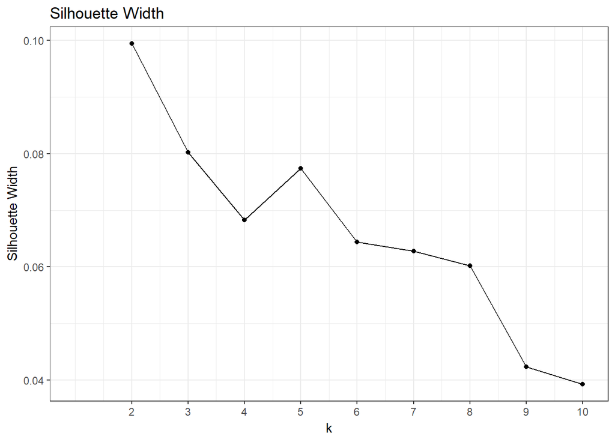

```r
silhouette_width <- calc_silhouette(diabetes_gower_dist, k = 10)

ggplot(data.frame(k = 1:10, silhouette_width),
       aes(x = k, y = silhouette_width)) +
  geom_point() +
  geom_line() +
  scale_x_continuous(breaks = 2:10, labels = 2:10) +
  labs(y="Silhouette Width", title="Silhouette Width") +
  theme_bw()
```

```r
pam_fit <- pam(diabetes_gower_dist, diss = TRUE, k = 4)
pam_fit_k5 <- pam(diabetes_gower_dist, diss = TRUE, k = 5)

diabetes_clean_sample %>%
  filter(row_number() %in% pam_fit$medoids) %>% kable()# View()
```

| patient_nbr | race | gender | age | weight | admission_type_id | discharge_disposition_id | admission_source_id | time_in_hospital | medical_specialty | num_lab_procedures | num_procedures | num_medications | number_outpatient | number_emergency | number_inpatient | diag_1 | diag_2 | diag_3 | number_diagnoses | max_glu_serum | A1Cresult | metformin | repaglinide | nateglinide | chlorpropamide | glimepiride | acetohexamide | glipizide | glyburide | … |
| --- | --- | --- | --- | --- | --- | --- | --- | --- | --- | --- | --- | --- | --- | --- | --- | --- | --- | --- | --- | --- | --- | --- | --- | --- | --- | --- | --- | --- | --- | --- |
| 110992860 | Caucasian | Male | [70-80) | NA | 1 | 1 | 7 | 1 | NA | 56 | 0 | 10 | 0 | 0 | 0 | 276 | 428 | 496 | 8 | None | None | No | No | No | No | No | No | No | No | … |
| 40875966 | Caucasian | Female | [60-70) | NA | 2 | 3 | 1 | 8 | NA | 13 | 2 | 19 | 1 | 0 | 3 | 998 | 682 | NA | 8 | None | None | No | No | No | No | No | No | No | No | … |
| 50247036 | Caucasian | Female | [80-90) | NA | 3 | 4 | 1 | 4 | NA | 34 | 1 | 20 | 0 | 0 | 0 | 250.1 | NA | NA | 1 | None | None | No | No | No | No | No | No | No | No | … |
| 6579963 | Caucasian | Female | [50-60) | NA | 1 | 1 | 6 | 3 | Surgery-General | 69 | 0 | 12 | 0 | 0 | 0 | 807 | NA | NA | 5 | None | None | No | No | No | No | No | No | No | Steady | … |

```r
diabetes_clean_sample %>%
  filter(row_number() %in% pam_fit_k5$medoids) %>% kable()
```

| patient_nbr | race | gender | age | weight | admission_type_id | discharge_disposition_id | admission_source_id | time_in_hospital | medical_specialty | num_lab_procedures | num_procedures | num_medications | number_outpatient | number_emergency | number_inpatient | diag_1 | diag_2 | diag_3 | number_diagnoses | max_glu_serum | A1Cresult | metformin | repaglinide | nateglinide | chlorpropamide | glimepiride | acetohexamide | glipizide | glyburide | … |
| --- | --- | --- | --- | --- | --- | --- | --- | --- | --- | --- | --- | --- | --- | --- | --- | --- | --- | --- | --- | --- | --- | --- | --- | --- | --- | --- | --- | --- | --- | --- |
| 110992860 | Caucasian | Male | [70-80) | NA | 1 | 1 | 7 | 1 | NA | 56 | 0 | 10 | 0 | 0 | 0 | 276 | 428 | 496 | 8 | None | None | No | No | No | No | No | No | No | No | … |
| 40875966 | Caucasian | Female | [60-70) | NA | 2 | 3 | 1 | 8 | NA | 13 | 2 | 19 | 1 | 0 | 3 | 998 | 682 | NA | 8 | None | None | No | No | No | No | No | No | No | No | … |
| 50247036 | Caucasian | Female | [80-90) | NA | 3 | 4 | 1 | 4 | NA | 34 | 1 | 20 | 0 | 0 | 0 | 250.1 | NA | NA | 1 | None | None | No | No | No | No | No | No | No | No | … |
| 35967501 | AfricanAmerican | Female | [10-20) | NA | 1 | 1 | 7 | 1 | NA | 45 | 0 | 6 | 0 | 1 | 3 | 250.13 | NA | NA | 1 | None | >8 | No | No | No | No | No | No | No | No | … |
| 2568159 | Caucasian | Female | [60-70) | NA | 1 | 5 | 6 | 6 | Orthopedics | 47 | 1 | 12 | 0 | 0 | 0 | 820 | NA | NA | 5 | None | None | Steady | No | No | No | No | No | No | Steady | … |

### Visualisation & Assessment

Looking at the t-SNE plot below (which allows visualisation of multi-variate data in a lower dimensional space), I have a few thoughts. There might be too many or too few clusters; there might be too many variables to adequately project into lower dimensions; there might be too many variables in general which is confusing the analysis. Next steps might be to use PCA

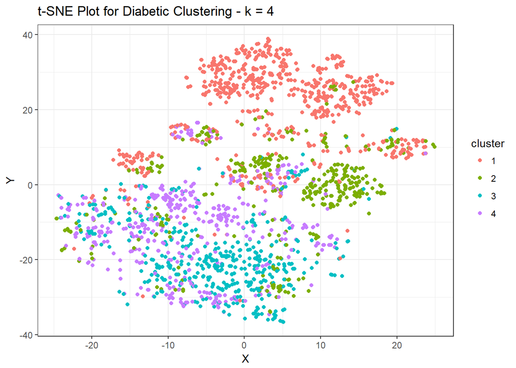

```r
diabetes_tsne <- Rtsne(diabetes_gower_dist, is_distance = TRUE)
diabetes_tsne_k5 <- Rtsne(diabetes_gower_dist, is_distance = TRUE)

diabetes_tsne_data <- diabetes_tsne$Y %>%
  data.frame() %>%
  setNames(c("X", "Y")) %>%
  mutate(cluster = factor(pam_fit$clustering),
         patient_nbr = diabetes_clean_sample$patient_nbr)

diabetes_tsne_data_k5 <- diabetes_tsne_k5$Y %>%
  data.frame() %>%
  setNames(c("X", "Y")) %>%
  mutate(cluster = factor(pam_fit_k5$clustering),
         patient_nbr = diabetes_clean_sample$patient_nbr)

diabetes_tsne_data %>%
  ggplot(aes(x = X, y = Y)) +
  geom_point(aes(color = cluster)) +
  theme_bw() +
  labs(title="t-SNE Plot for Diabetic Clustering - k = 4")
```

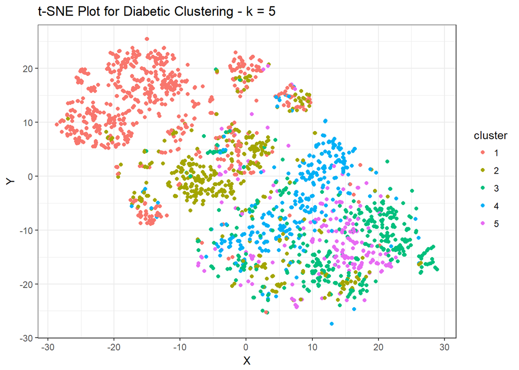

```r
diabetes_tsne_data_k5 %>%
  ggplot(aes(x = X, y = Y)) +
  geom_point(aes(color = cluster)) +
  theme_bw() +
  labs(title="t-SNE Plot for Diabetic Clustering - k = 5")
```

```r
diabetes_sample_mfa <-
  diabetes_clean_sample %>% select(-weight)
  MFA(group = c(1, 4, 3, 1,
                1, 6, 3,
                1, 27, 1),
      type = c("n", "n", "n", "s",
               "n", "s", "n",
               "s", "n", "n"),
      name.group=c("patient", "demographics", "admission", "admission_dur",
                   "specialty", "procedures", "diagnoses",
                   "num_diagnoses", "medication", "outcome"),
      num.group.sup = c(1, 10),
      graph = FALSE)
```